# 08 07 2020 - Tidy Tuesday - European Energy

Brett Moxham

07/08/2020

## Library and Data

Let’s load in our data and libraries. Our data comes from the [European Energy Tidy Tuesday data set.](https://github.com/rfordatascience/tidytuesday/blob/master/data/2020/2020-08-04/readme.md)

```r
library(tidyverse)


energy_types <- readr::read_csv('https://raw.githubusercontent.com/rfordatascience/tidytuesday/master/data/2020/2020-08-04/energy_types.csv')
country_totals <- readr::read_csv('https://raw.githubusercontent.com/rfordatascience/tidytuesday/master/data/2020/2020-08-04/country_totals.csv')
```

## Quick EDA

Let’s take a quick look at our data.

```r
skimr::skim(energy_types)
```

Data summary

| Name | energy_types |
| --- | --- |
| Number of rows | 296 |
| Number of columns | 7 |
| _______________________ |  |
| Column type frequency: |  |
| character | 4 |
| numeric | 3 |
| ________________________ |  |
| Group variables | None |

**Variable type: character**

| skim_variable | n_missing | complete_rate | min | max | empty | n_unique | whitespace |
| --- | --- | --- | --- | --- | --- | --- | --- |
| country | 0 | 1.00 | 2 | 2 | 0 | 37 | 0 |
| country_name | 8 | 0.97 | 5 | 20 | 0 | 36 | 0 |
| type | 0 | 1.00 | 4 | 20 | 0 | 8 | 0 |
| level | 0 | 1.00 | 7 | 7 | 0 | 2 | 0 |

**Variable type: numeric**

| skim_variable | n_missing | complete_rate | mean | sd | p0 | p25 | p50 | p75 | p100 | hist |
| --- | --- | --- | --- | --- | --- | --- | --- | --- | --- | --- |
| 2016 | 0 | 1 | 12783.36 | 41066.36 | 0 | 0 | 373.28 | 5677.25 | 390141.0 | ▇▁▁▁▁ |
| 2017 | 0 | 1 | 12910.96 | 41029.50 | 0 | 0 | 351.89 | 5924.46 | 379094.0 | ▇▁▁▁▁ |
| 2018 | 0 | 1 | 12796.20 | 39423.36 | 0 | 0 | 278.35 | 6790.15 | 393153.2 | ▇▁▁▁▁ |

In our `energy_types` data set we’ve got 37 different countries, however we are missing 1 country name it seems. Let see which one is missing.

```r
energy_types %>%
  filter(is.na(country_name))
```

```
## # A tibble: 8 x 7
##   country country_name type                 level    `2016`  `2017`  `2018`
##   <chr>   <chr>        <chr>                <chr>     <dbl>   <dbl>   <dbl>
## 1 UK      <NA>         Conventional thermal Level 1 203165. 189297. 180838.
## 2 UK      <NA>         Nuclear              Level 1  65149.  63887.  59098.
## 3 UK      <NA>         Hydro                Level 1   8287.   8723.   7679.
## 4 UK      <NA>         Pumped hydro power   Level 2   2949.   2862.   2516.
## 5 UK      <NA>         Wind                 Level 1  37263.  50004.  56904.
## 6 UK      <NA>         Solar                Level 1  10411.  11525.  12857.
## 7 UK      <NA>         Geothermal           Level 1      0       0       0
## 8 UK      <NA>         Other                Level 1      0       0       0
```

The United Kingdom is our country name that is missing. Lets fix that.

```r
energy_types <- energy_types %>%
  mutate(country_name = case_when(
    country == "UK" ~ "United Kingdom",
    TRUE ~ country_name
  ))


skimr::skim(energy_types)
```

Data summary

| Name | energy_types |
| --- | --- |
| Number of rows | 296 |
| Number of columns | 7 |
| _______________________ |  |
| Column type frequency: |  |
| character | 4 |
| numeric | 3 |
| ________________________ |  |
| Group variables | None |

**Variable type: character**

| skim_variable | n_missing | complete_rate | min | max | empty | n_unique | whitespace |
| --- | --- | --- | --- | --- | --- | --- | --- |
| country | 0 | 1 | 2 | 2 | 0 | 37 | 0 |
| country_name | 0 | 1 | 5 | 20 | 0 | 37 | 0 |
| type | 0 | 1 | 4 | 20 | 0 | 8 | 0 |
| level | 0 | 1 | 7 | 7 | 0 | 2 | 0 |

**Variable type: numeric**

| skim_variable | n_missing | complete_rate | mean | sd | p0 | p25 | p50 | p75 | p100 | hist |
| --- | --- | --- | --- | --- | --- | --- | --- | --- | --- | --- |
| 2016 | 0 | 1 | 12783.36 | 41066.36 | 0 | 0 | 373.28 | 5677.25 | 390141.0 | ▇▁▁▁▁ |
| 2017 | 0 | 1 | 12910.96 | 41029.50 | 0 | 0 | 351.89 | 5924.46 | 379094.0 | ▇▁▁▁▁ |
| 2018 | 0 | 1 | 12796.20 | 39423.36 | 0 | 0 | 278.35 | 6790.15 | 393153.2 | ▇▁▁▁▁ |

We’ve now got a full data set for `energy_types`.

Lets take a quick look at the `country_totals` data set.

```r
skimr::skim(country_totals)
```

Data summary

| Name | country_totals |
| --- | --- |
| Number of rows | 185 |
| Number of columns | 7 |
| _______________________ |  |
| Column type frequency: |  |
| character | 4 |
| numeric | 3 |
| ________________________ |  |
| Group variables | None |

**Variable type: character**

| skim_variable | n_missing | complete_rate | min | max | empty | n_unique | whitespace |
| --- | --- | --- | --- | --- | --- | --- | --- |
| country | 0 | 1.00 | 2 | 2 | 0 | 37 | 0 |
| country_name | 5 | 0.97 | 5 | 20 | 0 | 36 | 0 |
| type | 0 | 1.00 | 7 | 26 | 0 | 5 | 0 |
| level | 0 | 1.00 | 5 | 5 | 0 | 1 | 0 |

**Variable type: numeric**

| skim_variable | n_missing | complete_rate | mean | sd | p0 | p25 | p50 | p75 | p100 | hist |
| --- | --- | --- | --- | --- | --- | --- | --- | --- | --- | --- |
| 2016 | 1 | 0.99 | 45207.06 | 99814.70 | 0 | 1620.50 | 8426.0 | 29583.31 | 614155.0 | ▇▁▁▁▁ |
| 2017 | 0 | 1.00 | 45413.37 | 100337.16 | 0 | 2204.74 | 8189.7 | 30676.00 | 619059.0 | ▇▁▁▁▁ |
| 2018 | 0 | 1.00 | 45062.34 | 98010.77 | 0 | 2186.68 | 8326.0 | 31671.10 | 571799.7 | ▇▁▁▁▁ |

This time we have 5 `country_names` missing from our data set. Lets fix that as well.

```r
country_totals %>%
  filter(is.na(country_name))
```

```
## # A tibble: 5 x 7
##   country country_name type                       level  `2016`  `2017`  `2018`
##   <chr>   <chr>        <chr>                      <chr>   <dbl>   <dbl>   <dbl>
## 1 UK      <NA>         Total net production       Total 324274. 323440. 317376.
## 2 UK      <NA>         Imports                    Total  20018.  18167.  21332.
## 3 UK      <NA>         Exports                    Total   2273.   3407.   2225.
## 4 UK      <NA>         Energy absorbed by pumping Total   4014.   3859.   3391.
## 5 UK      <NA>         Energy supplied            Total 338005. 334340. 333092.
```

```r
country_totals <- country_totals %>%
  mutate(country_name = case_when(
    country == "UK" ~ "United Kingdom",
    TRUE ~ country_name
  ))


skimr::skim(country_totals)
```

Data summary

| Name | country_totals |
| --- | --- |
| Number of rows | 185 |
| Number of columns | 7 |
| _______________________ |  |
| Column type frequency: |  |
| character | 4 |
| numeric | 3 |
| ________________________ |  |
| Group variables | None |

**Variable type: character**

| skim_variable | n_missing | complete_rate | min | max | empty | n_unique | whitespace |
| --- | --- | --- | --- | --- | --- | --- | --- |
| country | 0 | 1 | 2 | 2 | 0 | 37 | 0 |
| country_name | 0 | 1 | 5 | 20 | 0 | 37 | 0 |
| type | 0 | 1 | 7 | 26 | 0 | 5 | 0 |
| level | 0 | 1 | 5 | 5 | 0 | 1 | 0 |

**Variable type: numeric**

| skim_variable | n_missing | complete_rate | mean | sd | p0 | p25 | p50 | p75 | p100 | hist |
| --- | --- | --- | --- | --- | --- | --- | --- | --- | --- | --- |
| 2016 | 1 | 0.99 | 45207.06 | 99814.70 | 0 | 1620.50 | 8426.0 | 29583.31 | 614155.0 | ▇▁▁▁▁ |
| 2017 | 0 | 1.00 | 45413.37 | 100337.16 | 0 | 2204.74 | 8189.7 | 30676.00 | 619059.0 | ▇▁▁▁▁ |
| 2018 | 0 | 1.00 | 45062.34 | 98010.77 | 0 | 2186.68 | 8326.0 | 31671.10 | 571799.7 | ▇▁▁▁▁ |

Now that we have our `country_names` updated. Lets actually take a look and see what is containted within our data sets.

```r
country_totals %>%
  head(10) %>%
  knitr::kable()
```

| country | country_name | type | level | 2016 | 2017 | 2018 |
| --- | --- | --- | --- | --- | --- | --- |
| BE | Belgium | Total net production | Total | 82520 | 82948.500 | 69212.347 |
| BE | Belgium | Imports | Total | 14648 | 14189.400 | 21635.908 |
| BE | Belgium | Exports | Total | 8465 | 8167.800 | 4308.347 |
| BE | Belgium | Energy absorbed by pumping | Total | 1475 | 1485.400 | 1347.901 |
| BE | Belgium | Energy supplied | Total | 87228 | 87484.700 | 85192.007 |
| BG | Bulgaria | Total net production | Total | 41221 | 41351.303 | 41705.000 |
| BG | Bulgaria | Imports | Total | 4568 | 3705.423 | 2223.000 |
| BG | Bulgaria | Exports | Total | 10940 | 9185.794 | 10030.000 |
| BG | Bulgaria | Energy absorbed by pumping | Total | 918 | 949.527 | 425.000 |
| BG | Bulgaria | Energy supplied | Total | 33931 | 34921.405 | 33473.000 |

```r
energy_types %>%
  head(10) %>%
  knitr::kable()
```

| country | country_name | type | level | 2016 | 2017 | 2018 |
| --- | --- | --- | --- | --- | --- | --- |
| BE | Belgium | Conventional thermal | Level 1 | 30728 | 31316.00 | 30092.635 |
| BE | Belgium | Nuclear | Level 1 | 41430 | 40128.50 | 26995.628 |
| BE | Belgium | Hydro | Level 1 | 1476 | 1360.90 | 1239.248 |
| BE | Belgium | Pumped hydro power | Level 2 | 1110 | 1093.20 | 983.190 |
| BE | Belgium | Wind | Level 1 | 5340 | 6387.90 | 7177.346 |
| BE | Belgium | Solar | Level 1 | 3070 | 3264.30 | 3488.979 |
| BE | Belgium | Geothermal | Level 1 | 0 | 0.00 | 0.000 |
| BE | Belgium | Other | Level 1 | 476 | 490.90 | 218.509 |
| BG | Bulgaria | Conventional thermal | Level 1 | 18909 | 20234.21 | 19334.000 |
| BG | Bulgaria | Nuclear | Level 1 | 14932 | 14718.37 | 15290.000 |

Looking at our `country_totals` data set, it looks like we have a summary of a countrys energy export/import. Where as the `energy_types` data set contains a breakdown of a countrys actual energy use by type. Looking at the `levels` vector, we have a `Level 2` level. A tweet from Tom Mock outlines that we do not need to factor this into our data, as it is a subset of `hydro`. [This means to include it would be to double count `hydro`.](https://twitter.com/thomas_mock/status/1290771994192023554) We can filter these entries out. Our raw energy totals are in [Gigawatt Hours](https://github.com/rfordatascience/tidytuesday/blob/master/data/2020/2020-08-04/readme.md)

```r
energy_type_l2 <- energy_types %>%
  filter(level != "Level 2")
```

## Visualization

I want visalize a breakdown of each country’s energy use by production method for the year of 2018. Lets see what we can come up with.

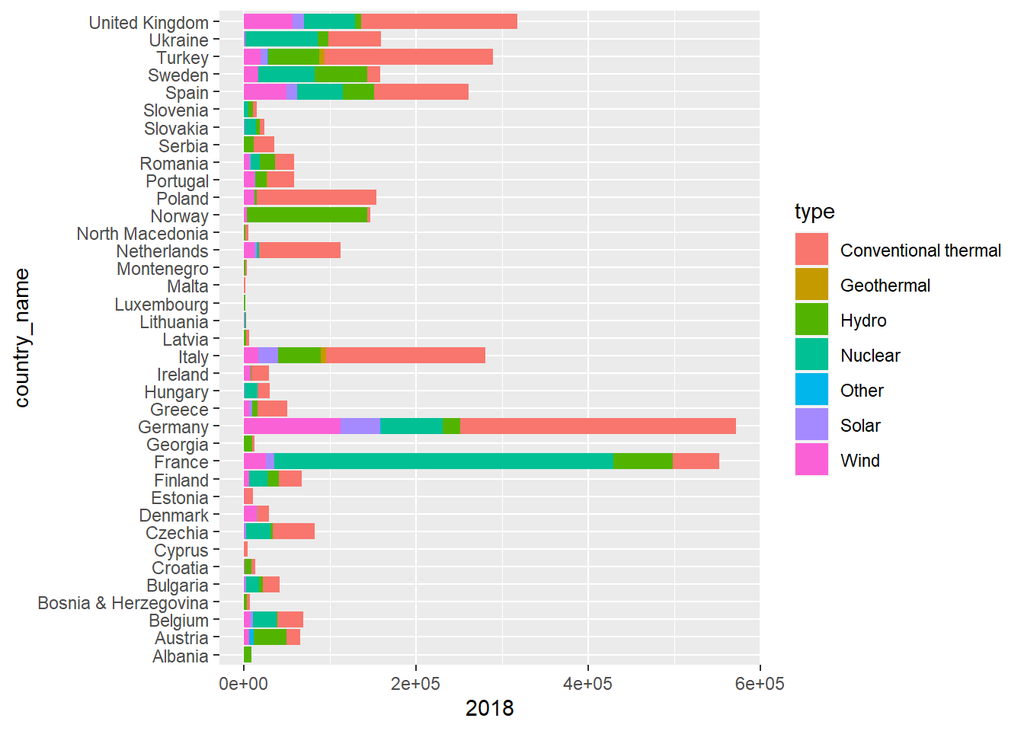

```r
energy_type_l2 %>%
  select(-c(`2016`,`2017`)) %>%
  ggplot(aes(country_name, `2018`, fill = type))+ #try and get a reorder
  geom_col()+
  coord_flip() ->p_0


p_0
```

This first plot is nice but it’s hard to compare between countries. We need to reorder our country name somehow. Let add together the total energy usage by `type` to see how much total energy each country used and use that to order our plot.

```r
energy_total <- energy_type_l2 %>%
  select(-c(`2016`, `2017`)) %>%
  group_by(country_name) %>%
  mutate(
    energy_total = sum(`2018`)/1000,
    `2018` = `2018`/1000

  )

energy_total
```

```
## # A tibble: 259 x 6
## # Groups:   country_name [37]
##    country country_name type                 level   `2018` energy_total
##    <chr>   <chr>        <chr>                <chr>    <dbl>        <dbl>
##  1 BE      Belgium      Conventional thermal Level 1 30.1           69.2
##  2 BE      Belgium      Nuclear              Level 1 27.0           69.2
##  3 BE      Belgium      Hydro                Level 1  1.24          69.2
##  4 BE      Belgium      Wind                 Level 1  7.18          69.2
##  5 BE      Belgium      Solar                Level 1  3.49          69.2
##  6 BE      Belgium      Geothermal           Level 1  0             69.2
##  7 BE      Belgium      Other                Level 1  0.219         69.2
##  8 BG      Bulgaria     Conventional thermal Level 1 19.3           41.7
##  9 BG      Bulgaria     Nuclear              Level 1 15.3           41.7
## 10 BG      Bulgaria     Hydro                Level 1  4.69          41.7
## # ... with 249 more rows
```

Now lets try making our graph again.

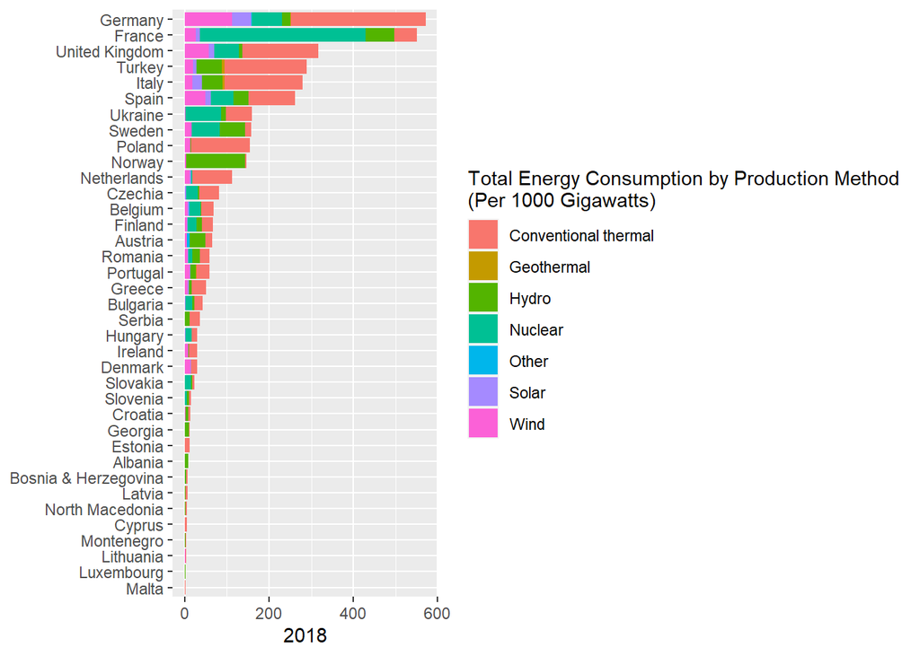

```r
energy_total %>%
  ggplot(aes(fct_reorder(country_name, energy_total), `2018`, fill = type))+
  geom_col()+
  theme(
    #axis.title.x = element_blank(),
    axis.title.y = element_blank()
  )+
  labs(
    fill = "Total Energy Consumption by Production Method
(Per 1000 Gigawatts)")+
  coord_flip() -> p_1

p_1
```

This is a lot easier to read! We can see how Germany France and the U.K. are Europe’s largest consumer of energy. However this also makes it difficult to compare the largest energy consumers to the smallest. Let’s see if we can look at the proportion of energy used by each instead. We start by building a proportion column.

```r
energy_prop <- energy_total %>%
  group_by(country) %>%
  mutate(
    prop = `2018`/energy_total
  )
```

We now have a proportion of energy consumption by type that we can use to compare each country. Lets take a look.

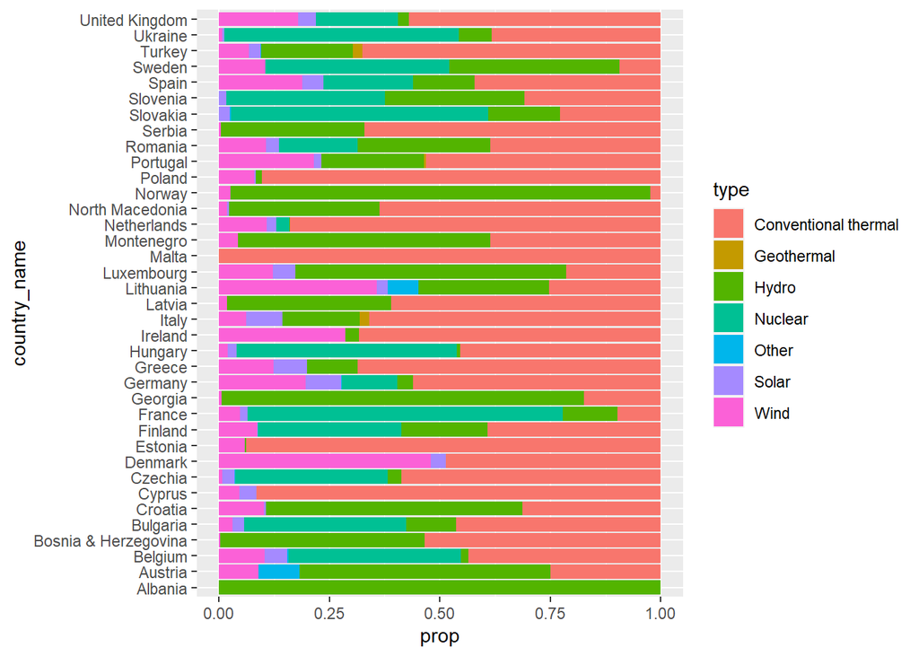

```r
energy_prop %>%
  ggplot(aes(country_name, prop , fill = type))+
  geom_col()+
  coord_flip()
```

This is cool, we have a way to compare countries in their energy use. For instance on the bottom, we can see that Albania uses nearly all `hyrdo` power as their many energy source. Lets put them in order of their total energy consumption so that we can reference total energy to their proportion of use.

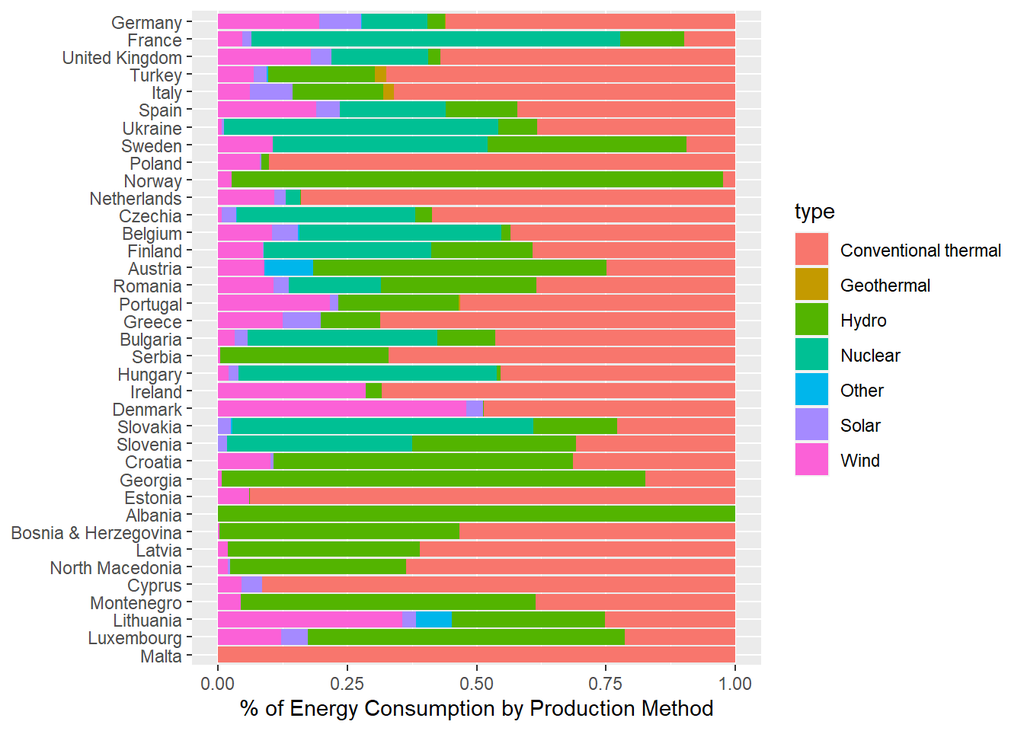

```r
energy_prop %>%
  ggplot(aes(fct_reorder(country_name, energy_total), prop, fill = type))+
  geom_col()+
 # scale_y_continuous(labels = scales::percent)+
  coord_flip() +
    theme(
    #axis.title.x = element_blank(),
    axis.title.y = element_blank()
  )+
  labs(
    y = "% of Energy Consumption by Production Method"
  ) -> p_2

p_2
```

Now that we have our two plots in the same order, lets take a look at them side by side.

```r
plot_joined <-  cowplot::plot_grid(p_1, p_2, cols = 2)
```

[figure not shown]

```r
plot_joined
```

This is a super neat plot. Some insights provided by this graph:

- Germany, The Netherlands and Poland still have work to do in terms of their conventional energy use.
- France is the largest user of nuclear energy in both absolute and relative terms.
- Norway and Albania both receieve over 95% of their energy from hydro power